# Predict Bike Sharing Demand with AutoGluon

### Feature Engineering — Advanced Feature Set

```python
# Re-combine train+test for consistent feature engineering
df = pd.concat([train, test], axis=0, ignore_index=True)

# 1. Parse datetime and extract temporal features
df['datetime']   = pd.to_datetime(df['datetime'])
df['hour']       = df['datetime'].dt.hour
df['dayofmonth'] = df['datetime'].dt.day
df['dayofweek']  = df['datetime'].dt.dayofweek
df['month']      = df['datetime'].dt.month
df['year']       = df['datetime'].dt.year

# 2. Drop columns not needed for modelling
df.drop(['datetime', 'casual', 'registered'], axis=1, inplace=True)

# 3. Advanced engineered features
df['temp_diff'] = abs(df['temp'] - df['atemp'])           # perceived-vs-actual gap
df['is_peak']   = ((df['workingday'] == 1) &
                   (df['hour'].isin([8, 17, 18]))).astype(int)  # rush-hour flag

# 4. One-hot encode season and weather
df = pd.get_dummies(df, columns=['season', 'weather'], drop_first=True)

# 5. Rename for readability
df.rename(columns={
    'season_2':'summer','season_3':'fall','season_4':'winter',
    'weather_2':'cloudy','weather_3':'rainy','weather_4':'heavy_storm',
    'workingday':'is_workingday','holiday':'is_holiday'
}, inplace=True)

print(df.columns.tolist())
df.tail(3)
```

```
['is_holiday', 'is_workingday', 'temp', 'atemp', 'humidity', 'windspeed', 'count', 'hour', 'dayofmonth', 'dayofweek', 'month', 'year', 'temp_diff', 'is_peak', 'summer', 'fall', 'winter', 'cloudy', 'rainy', 'heavy_storm']
```

|  | is_holiday | is_workingday | temp | atemp | humidity | windspeed | count | hour | dayofmonth | dayofweek | month | year | temp_diff | is_peak | summer | fall | winter | cloudy | rainy | heavy_storm |
| --- | --- | --- | --- | --- | --- | --- | --- | --- | --- | --- | --- | --- | --- | --- | --- | --- | --- | --- | --- | --- |
| 17376 | 0 | 1 | 10.66 | 12.880 | 60 | 11.0014 | NaN | 21 | 31 | 0 | 12 | 2012 | 2.220 | 0 | False | False | False | False | False | False |
| 17377 | 0 | 1 | 10.66 | 13.635 | 56 | 8.9981 | NaN | 22 | 31 | 0 | 12 | 2012 | 2.975 | 0 | False | False | False | False | False | False |
| 17378 | 0 | 1 | 10.66 | 13.635 | 65 | 8.9981 | NaN | 23 | 31 | 0 | 12 | 2012 | 2.975 | 0 | False | False | False | False | False | False |

```python
# 6. Split back into engineered train/test
train_fe = df[df['count'].notnull()].copy()
test_fe  = df[df['count'].isnull()].drop(['count'], axis=1)
print(f'train_fe: {train_fe.shape}   test_fe: {test_fe.shape}')
```

```
train_fe: (10886, 20)   test_fe: (6493, 19)
```

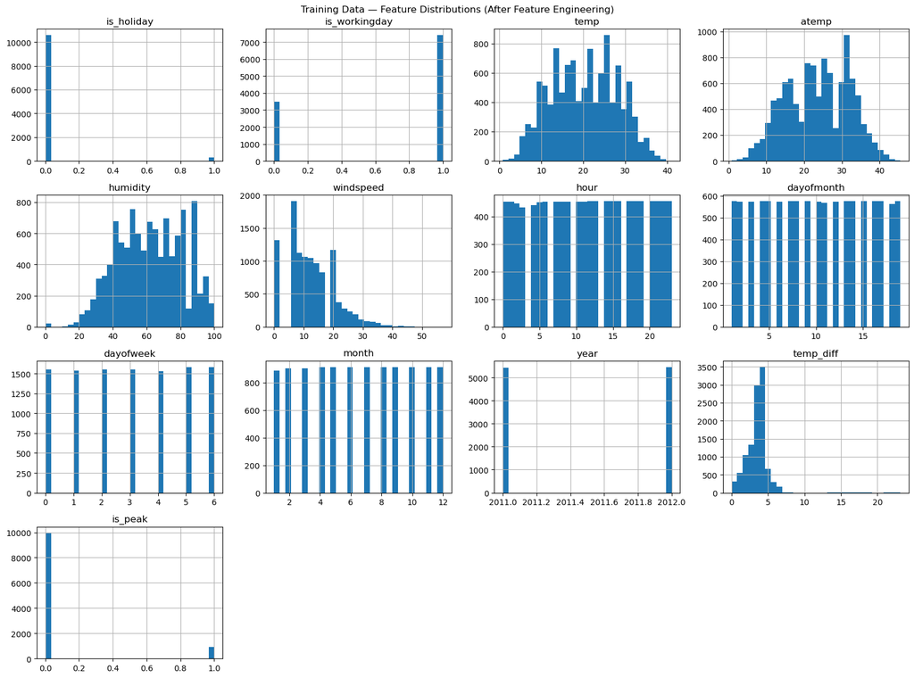

```
Saved img/eda_histograms_after.png
```

```python
# Histogram of features AFTER engineering — now includes hour, temp_diff, is_peak etc.
train_fe.drop(columns=['count']).select_dtypes(include='number').hist(
    bins=30, figsize=(16, 12))
plt.suptitle('Training Data — Feature Distributions (After Feature Engineering)')
plt.tight_layout()
plt.savefig('img/eda_histograms_after.png', dpi=100)
plt.show()
print('Saved img/eda_histograms_after.png')
```

## Step 5: Rerun the Model with the Same Settings, Just with More Features

```python
X_fe = train_fe.drop(columns=['count'])
y_fe = train_fe['count']

X_tr_fe, X_val_fe, y_tr_fe, y_val_fe = train_test_split(
    X_fe, y_fe, test_size=0.2, random_state=42)

predictor_new_features = RandomForestRegressor(
    n_estimators=600, max_depth=25, random_state=32, n_jobs=-1)
predictor_new_features.fit(X_tr_fe, y_tr_fe)

rmse_fe_tr  = np.sqrt(mean_squared_error(y_tr_fe,  predictor_new_features.predict(X_tr_fe)))
rmse_fe_val = np.sqrt(mean_squared_error(y_val_fe, predictor_new_features.predict(X_val_fe)))
mae_fe      = mean_absolute_error(y_val_fe, predictor_new_features.predict(X_val_fe))
r2_fe       = predictor_new_features.score(X_tr_fe, y_tr_fe)
print(f'Add-features — R²(train): {r2_fe:.2f}  RMSE train: {rmse_fe_tr:.2f}  val: {rmse_fe_val:.2f}  MAE val: {mae_fe:.2f}')
```

```
Add-features — R²(train): 0.99  RMSE train: 15.21  val: 40.28  MAE val: 25.43
```

```python
pd.Series(predictor_new_features.feature_importances_, index=X_fe.columns)\
  .sort_values(ascending=False)
```

```
hour             0.442895
is_peak          0.182396
year             0.096676
atemp            0.060153
month            0.054781
temp             0.046455
humidity         0.029523
is_workingday    0.022361
dayofweek        0.020115
rainy            0.013627
dayofmonth       0.009984
windspeed        0.008227
temp_diff        0.007583
cloudy           0.001449
is_holiday       0.001074
summer           0.001053
winter           0.000860
fall             0.000727
heavy_storm      0.000061
dtype: float64
```

```python
new_features_preds = np.maximum(0, predictor_new_features.predict(test_fe))
sub_fe = pd.read_csv('bike-sharing-demand/sampleSubmission.csv')
sub_fe['count'] = new_features_preds

output_path = 'submission_new_features.csv'
if os.path.exists(output_path):
    print(f'File "{output_path}" already exists — overwriting with updated predictions.')
else:
    print(f'File "{output_path}" not found — creating new file.')

sub_fe.to_csv(output_path, index=False)
print(f'Saved → {output_path}')
sub_fe.head()
```

```
File "submission_new_features.csv" already exists — overwriting with updated predictions.
Saved → submission_new_features.csv
```

|  | datetime | count |
| --- | --- | --- |
| 0 | 2011-01-20 00:00:00 | 15.008333 |
| 1 | 2011-01-20 01:00:00 | 7.386667 |
| 2 | 2011-01-20 02:00:00 | 5.526667 |
| 3 | 2011-01-20 03:00:00 | 3.740000 |
| 4 | 2011-01-20 04:00:00 | 3.101667 |

#### New Score (add_features): `0.48074` (Kaggle RMSLE)

### 💬 Observation — Model After Feature Engineering

**How much better did your model perform after adding additional features and why?**

[output not shown]

## Step 6: Hyperparameter Optimization

Tuned `n_estimators`, `max_depth`, and `min_samples_split`. More trees and greater depth capture more variance but risk overfitting.

```python
predictor_new_hpo = RandomForestRegressor(
    n_estimators=800, max_depth=40, min_samples_split=2,
    random_state=67, n_jobs=-1)
predictor_new_hpo.fit(X_tr_fe, y_tr_fe)

rmse_hpo_tr  = np.sqrt(mean_squared_error(y_tr_fe,  predictor_new_hpo.predict(X_tr_fe)))
rmse_hpo_val = np.sqrt(mean_squared_error(y_val_fe, predictor_new_hpo.predict(X_val_fe)))
r2_hpo       = predictor_new_hpo.score(X_tr_fe, y_tr_fe)
print(f'HPO — R²(train): {r2_hpo:.2f}  RMSE train: {rmse_hpo_tr:.2f}  val: {rmse_hpo_val:.2f}')
```

```
HPO — R²(train): 0.99  RMSE train: 15.18  val: 40.19
```

```python
new_hpo_preds = np.maximum(0, predictor_new_hpo.predict(test_fe))
sub_hpo = pd.read_csv('bike-sharing-demand/sampleSubmission.csv')
sub_hpo['count'] = new_hpo_preds

output_path = 'submission_new_hpo.csv'
if os.path.exists(output_path):
    print(f'File "{output_path}" already exists — overwriting with updated predictions.')
else:
    print(f'File "{output_path}" not found — creating new file.')

sub_hpo.to_csv(output_path, index=False)
print(f'Saved → {output_path}')
sub_hpo.head()
```

```
File "submission_new_hpo.csv" already exists — overwriting with updated predictions.
Saved → submission_new_hpo.csv
```

|  | datetime | count |
| --- | --- | --- |
| 0 | 2011-01-20 00:00:00 | 15.24375 |
| 1 | 2011-01-20 01:00:00 | 7.34250 |
| 2 | 2011-01-20 02:00:00 | 5.49750 |
| 3 | 2011-01-20 03:00:00 | 3.63375 |
| 4 | 2011-01-20 04:00:00 | 2.99875 |

#### New Score (hpo): `0.48198` (Kaggle RMSLE)

### 💬 Observation — HPO Results

[output not shown]

**Given more time:**

- Lag/rolling demand features (same hour, past 7 days)
- LightGBM or XGBoost (10–20% better on tabular tasks)
- Time-based cross-validation to prevent future leakage